# MD3 Demo

Stephen Vaisey

2022-09-13

Install new package (h/t Andrew Weatherman) for college basketball data. (Don’t forget `eval = FALSE` in the code chunk!)

```r
install.packages("toRvik")
```

Let’s load the packages we will need.

```r
library(toRvik)
library(tidyverse)
```

I’m going to grab player data by game in 2022. I’m going to add `cache = TRUE` to the chunk options so I don’t have to re-download the data every time.

```r
pg <- bart_player_game(year = 2022,
                       stat = "box")
```

We are going to learn several `dplyr` verbs using this dataset. The main ones are:

- `filter()`
- `summarize()`
- `group_by()`
- `mutate()`
- `arrange()`

Before we use these, let’s `glimpse()` the data. (Note that `glimpse()` is also a verb!)

```r
glimpse(pg)
```

```
## Rows: 108,177
## Columns: 28
## $ date    <chr> "2021-11-09", "2021-11-12", "2021-11-18", "2021-11-25", "2021-…
## $ year    <dbl> 2022, 2022, 2022, 2022, 2022, 2022, 2022, 2022, 2022, 2022, 20…
## $ player  <chr> "Jalen Coleman-Lands", "Jalen Coleman-Lands", "Jalen Coleman-L…
## $ exp     <chr> "Sr", "Sr", "Sr", "Sr", "Sr", "Sr", "Sr", "Sr", "Sr", "Sr", "S…
## $ team    <chr> "Kansas", "Kansas", "Kansas", "Kansas", "Kansas", "Kansas", "K…
## $ conf    <chr> "B12", "B12", "B12", "B12", "B12", "B12", "B12", "B12", "B12",…
## $ opp     <chr> "Michigan St.", "Tarleton St.", "Stony Brook", "North Texas", …
## $ result  <chr> "W", "W", "W", "W", "L", "W", "W", "W", "W", "W", "W", "W", "W…
## $ min     <dbl> 10, 12, 15, 10, 8, 5, 5, 10, 12, 4, 6, 25, 14, 20, 14, 9, 5, 4…
## $ pts     <dbl> 5, 10, 7, 0, 0, 0, 3, 6, 8, 2, 2, 20, 6, 5, 3, 6, 2, 0, 2, 2, …
## $ two_m   <dbl> 0, 2, 2, 0, 0, 0, 0, 1, 1, 0, 1, 2, 0, 0, 0, 1, 1, 0, 1, 1, 0,…
## $ two_a   <dbl> 2, 2, 2, 1, 1, 0, 1, 1, 1, 0, 2, 2, 1, 0, 0, 3, 1, 0, 1, 2, 2,…
## $ three_m <dbl> 1, 2, 1, 0, 0, 0, 1, 1, 2, 0, 0, 5, 2, 1, 0, 1, 0, 0, 0, 0, 2,…
## $ three_a <dbl> 3, 2, 2, 0, 2, 0, 4, 3, 2, 1, 2, 7, 3, 6, 2, 1, 0, 1, 1, 0, 3,…
## $ fgm     <dbl> 1, 4, 3, 0, 0, 0, 1, 2, 3, 0, 1, 7, 2, 1, 0, 2, 1, 0, 1, 1, 2,…
## $ fga     <dbl> 5, 4, 4, 1, 3, 0, 5, 4, 3, 1, 4, 9, 4, 6, 2, 4, 1, 1, 2, 2, 5,…
## $ ftm     <dbl> 2, 0, 0, 0, 0, 0, 0, 1, 0, 2, 0, 1, 0, 2, 3, 1, 0, 0, 0, 0, 0,…
## $ fta     <dbl> 3, 0, 0, 0, 0, 0, 0, 2, 0, 2, 0, 2, 0, 2, 3, 1, 0, 0, 0, 0, 0,…
## $ oreb    <dbl> 0, 0, 0, 0, 0, 0, 0, 0, 1, 0, 0, 0, 0, 0, 1, 0, 0, 0, 0, 0, 0,…
## $ dreb    <dbl> 0, 0, 0, 0, 0, 0, 0, 0, 1, 0, 0, 2, 1, 0, 2, 1, 1, 1, 1, 0, 2,…
## $ reb     <dbl> 0, 0, 0, 0, 0, 0, 0, 0, 2, 0, 0, 2, 1, 0, 3, 1, 1, 1, 1, 0, 2,…
## $ ast     <dbl> 1, 0, 2, 0, 1, 1, 0, 0, 2, 0, 0, 3, 0, 1, 0, 0, 0, 0, 0, 0, 0,…
## $ tov     <dbl> 1, 1, 0, 1, 0, 0, 0, 1, 0, 1, 1, 1, 1, 1, 0, 1, 3, 0, 0, 0, 1,…
## $ stl     <dbl> 0, 1, 1, 0, 0, 0, 0, 1, 2, 0, 0, 0, 0, 0, 1, 0, 0, 0, 0, 0, 0,…
## $ blk     <dbl> 0, 0, 0, 0, 0, 0, 0, 0, 0, 0, 0, 2, 0, 0, 1, 0, 0, 0, 0, 0, 0,…
## $ pf      <dbl> 1, 0, 1, 1, 1, 1, 1, 0, 1, 0, 0, 5, 1, 4, 2, 2, 1, 0, 1, 1, 1,…
## $ id      <chr> "40204", "40204", "40204", "40204", "40204", "40204", "40204",…
## $ game_id <chr> "KansasMichigan St.11-9", "Tarleton St.Kansas11-12", "Stony Br…
```

There are 108177 rows in this dataset. Each one corresponds to one player’s performance in one game in the 2021-22 season.

There are lots of variables here we could use. For example:

- `pts` is points scored
- `fga` is field goals attempted
- `fgm` is field goals made

These data come from all 32 Division I conferences. Let’s use the `count()` verb to check this out.

```r
pg |> count(conf)
```

```
## ── Player Game Stats ─────────────────────────────────────────── toRvik 1.1.0 ──
```

```
## ℹ Data updated: 2022-09-12 16:58:37 EDT
```

```
## # A tibble: 32 × 2
##    conf      n
##    <chr> <int>
##  1 A10    4263
##  2 ACC    4877
##  3 AE     2876
##  4 Amer   3491
##  5 ASun   3423
##  6 B10    4716
##  7 B12    3534
##  8 BE     3414
##  9 BSky   3265
## 10 BSth   3299
## # … with 22 more rows
```

This might be too much. We can use the `filter()` verb to limit our exploration to the ACC.

```r
pg_acc <- pg |>
  filter(conf == "ACC")
```

Now we have a new dataframe: `pg_acc`. Let’s confirm that it only has teams from the ACC.

```r
pg_acc |> count(team)
```

```
## ── Player Game Stats ─────────────────────────────────────────── toRvik 1.1.0 ──
```

```
## ℹ Data updated: 2022-09-12 16:58:37 EDT
```

```
## # A tibble: 15 × 2
##    team                   n
##    <chr>              <int>
##  1 Boston College       302
##  2 Clemson              325
##  3 Duke                 375
##  4 Florida St.          348
##  5 Georgia Tech         278
##  6 Louisville           343
##  7 Miami FL             347
##  8 North Carolina       385
##  9 North Carolina St.   297
## 10 Notre Dame           262
## 11 Pittsburgh           296
## 12 Syracuse             304
## 13 Virginia             323
## 14 Virginia Tech        346
## 15 Wake Forest          346
```

We can also use `filter()` without creating a new dataframe. For example, we could filter the dataframe to just Duke and see how many games each player played. We use the `count()` variable to count the number of rows for each player.

```r
pg_acc |>                    # start with ACC player data
  filter(team == "Duke") |>  # keep Duke rows
  count(player)              # count player appearances
```

```
## ── Player Game Stats ─────────────────────────────────────────── toRvik 1.1.0 ──
```

```
## ℹ Data updated: 2022-09-12 16:58:37 EDT
```

```
## # A tibble: 14 × 2
##    player                 n
##    <chr>              <int>
##  1 AJ Griffin            39
##  2 Bates Jones           27
##  3 Jaylen Blakes         21
##  4 Jeremy Roach          39
##  5 Joey Baker            34
##  6 Keenan Worthington     9
##  7 Mark Williams         39
##  8 Michael Savarino      11
##  9 Paolo Banchero        39
## 10 Spencer Hubbard        3
## 11 Stanley Borden         1
## 12 Theo John             38
## 13 Trevor Keels          36
## 14 Wendell Moore Jr.     39
```

Note that this is simply the number of rows in which each player appears in the dataset. Since each row is a game in which a player plays, the count is just the number of games a player played in.

This is great but it’s probably not in the order we want. We can add the `arrange()` verb to the bottom of the pipeline to control this.

```r
pg_acc |>
  filter(team == "Duke") |>
  count(player) |>
  arrange(n)                 # sort by the number of appearances
```

```
## ── Player Game Stats ─────────────────────────────────────────── toRvik 1.1.0 ──
```

```
## ℹ Data updated: 2022-09-12 16:58:37 EDT
```

```
## # A tibble: 14 × 2
##    player                 n
##    <chr>              <int>
##  1 Stanley Borden         1
##  2 Spencer Hubbard        3
##  3 Keenan Worthington     9
##  4 Michael Savarino      11
##  5 Jaylen Blakes         21
##  6 Bates Jones           27
##  7 Joey Baker            34
##  8 Trevor Keels          36
##  9 Theo John             38
## 10 AJ Griffin            39
## 11 Jeremy Roach          39
## 12 Mark Williams         39
## 13 Paolo Banchero        39
## 14 Wendell Moore Jr.     39
```

If we want to sort it in *descending* order, we wrap the ordering variable in `desc()`, like this:

```r
pg_acc |>
  filter(team == "Duke") |>
  count(player) |>
  arrange(desc(n))
```

```
## ── Player Game Stats ─────────────────────────────────────────── toRvik 1.1.0 ──
```

```
## ℹ Data updated: 2022-09-12 16:58:37 EDT
```

```
## # A tibble: 14 × 2
##    player                 n
##    <chr>              <int>
##  1 AJ Griffin            39
##  2 Jeremy Roach          39
##  3 Mark Williams         39
##  4 Paolo Banchero        39
##  5 Wendell Moore Jr.     39
##  6 Theo John             38
##  7 Trevor Keels          36
##  8 Joey Baker            34
##  9 Bates Jones           27
## 10 Jaylen Blakes         21
## 11 Michael Savarino      11
## 12 Keenan Worthington     9
## 13 Spencer Hubbard        3
## 14 Stanley Borden         1
```

Using `count()` is fine for a quick glance at frequencies. But using `summarize()` gives us more control at the cost of being a bit trickier to use at first.

We can start by getting the exact same thing as `count()`. First we’ll try something that **doesn’t work as intended** and then we will look at something that *does* work.

```r
pg_acc |>
  filter(team == "Duke") |>
  summarize(n = n())
```

```
## # A tibble: 1 × 1
##       n
##   <int>
## 1   375
```

What is happening here? This counts the total number of games played by *all* Duke players in 2021-22. If we want it separately for each player, we need to use one of the most useful `dplyr` verbs: `group_by()`. This verb performs *every subsequent operation in the pipeline* separately for each individual value of that variable. Here we’re going to `group_by(player)` to calculate the number of appearances separately by player.

```r
pg_acc |>
  filter(team == "Duke") |>
  group_by(player) |>
  summarize(n = n()) |>
  arrange(desc(n))
```

```
## # A tibble: 14 × 2
##    player                 n
##    <chr>              <int>
##  1 AJ Griffin            39
##  2 Jeremy Roach          39
##  3 Mark Williams         39
##  4 Paolo Banchero        39
##  5 Wendell Moore Jr.     39
##  6 Theo John             38
##  7 Trevor Keels          36
##  8 Joey Baker            34
##  9 Bates Jones           27
## 10 Jaylen Blakes         21
## 11 Michael Savarino      11
## 12 Keenan Worthington     9
## 13 Spencer Hubbard        3
## 14 Stanley Borden         1
```

This is more involved than `count()` but now we’re not stuck with just one new variable. We can create as many new variables as we want. We have to make up a new variable name and use *functions* that will create that new variable out of an existing variable.

We could do this using a lot of different functions. Let’s look at some examples.

```r
pg_acc |>
  filter(team == "Duke") |>
  group_by(player) |>
  summarize(n = n(),
            mean_pts = mean(pts),   # average per game
            total_pts = sum(pts),   # total from all games
            max_pts = max(pts)) |>  # max pts in single game
  arrange(desc(mean_pts))
```

```
## # A tibble: 14 × 5
##    player                 n mean_pts total_pts max_pts
##    <chr>              <int>    <dbl>     <dbl>   <dbl>
##  1 Paolo Banchero        39   17.2         671      28
##  2 Wendell Moore Jr.     39   13.4         523      26
##  3 Trevor Keels          36   11.5         413      27
##  4 Mark Williams         39   11.2         438      28
##  5 AJ Griffin            39   10.4         405      27
##  6 Jeremy Roach          39    8.62        336      19
##  7 Joey Baker            34    4.5         153      13
##  8 Theo John             38    2.82        107      10
##  9 Bates Jones           27    1.44         39       7
## 10 Michael Savarino      11    1.09         12       3
## 11 Jaylen Blakes         21    1            21       5
## 12 Keenan Worthington     9    0.333         3       2
## 13 Spencer Hubbard        3    0.333         1       1
## 14 Stanley Borden         1    0             0       0
```

We used three different functions here: `mean()`, `sum()`, and `max()` and used them to create new variables. (We could also use `arrange()` if we wanted to sort the table by any of these but you’ve seen that already.)

Of course, we didn’t have to group by player. Let’s group by “experience” (class) for the whole ACC instead:

```r
pg_acc |>
  group_by(exp) |>
  summarize(total_pts = sum(pts)) |>
  arrange(desc(total_pts))
```

```
## # A tibble: 4 × 2
##   exp   total_pts
##   <chr>     <dbl>
## 1 Sr        14675
## 2 Jr         8443
## 3 So         8163
## 4 Fr         5428
```

This is nice and all, but why not plot it? We can pipe a tibble we’ve created directly into `ggplot()` if we want. This will often give us a little more control over what we want to see.

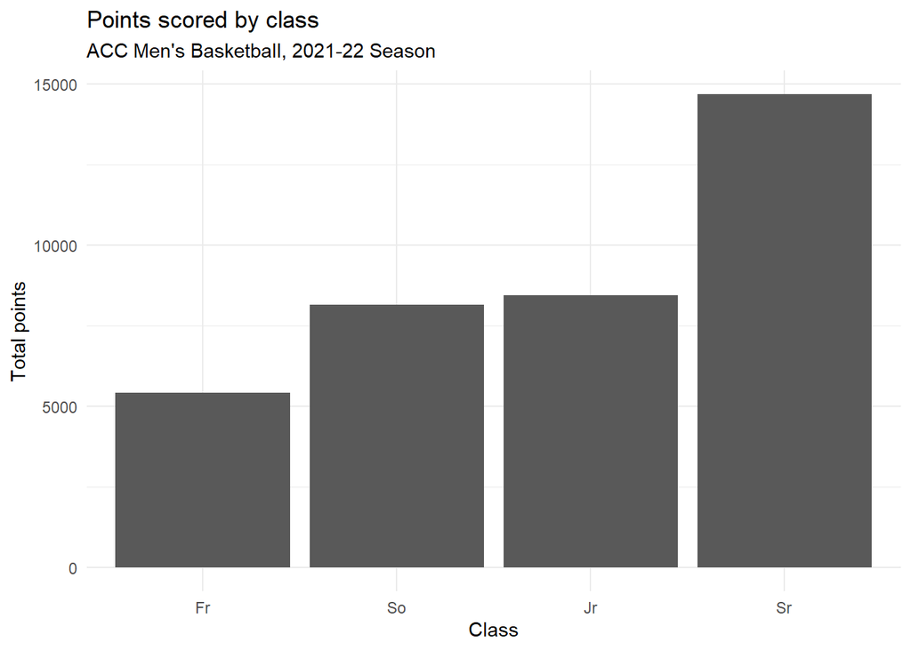

```r
pg_acc |>
  group_by(exp) |>
  summarize(total_pts = sum(pts)) |>
  ggplot(aes(x = reorder(exp, total_pts),  # graph starts here
             y = total_pts)) +
  geom_bar(stat = "identity") +
  theme_minimal() +
  labs(x = "Class",
       y = "Total points",
       title = "Points scored by class",
       subtitle = "ACC Men's Basketball, 2021-22 Season")
```

I saw a lot of you were fighting with `ggplot()` to reorder x-axes on, for example, bar graphs. This is normal; I often fight with them myself. One way to get around this is to make the tibble you want first before sending it to `ggplot()`.

Here’s an example. We can use `mutate()` to create the variables we want without having to try to get them right within the `ggplot()` syntax. In this example, we are using `case_when()` to map an old variable (`exp`) to a new variable (`class`). We are also creating a numeric version (`class_num`) to make it easier to sort the x-axis the way we want. Be warned: `case_when()` is tricky but really powerful once you get it figured out.

```r
pg_acc2 <- pg_acc |>
  mutate(
    class = case_when(
      exp == "Fr" ~ "1st Year",
      exp == "So" ~ "Sophomore",
      exp == "Jr" ~ "Junior",
      exp == "Sr" ~ "Senior"),
    class_num = case_when(
      exp == "Fr" ~ 1,
      exp == "So" ~ 2,
      exp == "Jr" ~ 3,
      exp == "Sr" ~ 4))

glimpse(pg_acc2)
```

```
## Rows: 4,877
## Columns: 30
## $ date      <chr> "2021-11-09", "2021-11-13", "2021-11-16", "2021-11-21", "202…
## $ year      <dbl> 2022, 2022, 2022, 2022, 2022, 2022, 2022, 2022, 2022, 2022, …
## $ player    <chr> "Charlie Moore", "Charlie Moore", "Charlie Moore", "Charlie …
## $ exp       <chr> "Sr", "Sr", "Sr", "Sr", "Sr", "Sr", "Sr", "Sr", "Sr", "Sr", …
## $ team      <chr> "Miami FL", "Miami FL", "Miami FL", "Miami FL", "Miami FL", …
## $ conf      <chr> "ACC", "ACC", "ACC", "ACC", "ACC", "ACC", "ACC", "ACC", "ACC…
## $ opp       <chr> "Canisius", "UCF", "Florida Atlantic", "Florida A&M", "Dayto…
## $ result    <chr> "W", "L", "W", "W", "L", "W", "L", "W", "W", "W", "W", "W", …
## $ min       <dbl> 36, 27, 27, 29, 27, 34, 29, 29, 35, 29, 38, 31, 29, 33, 37, …
## $ pts       <dbl> 13, 4, 8, 20, 2, 16, 12, 12, 8, 8, 18, 9, 7, 18, 25, 18, 20,…
## $ two_m     <dbl> 5, 0, 3, 1, 1, 4, 3, 3, 2, 4, 5, 1, 1, 3, 2, 6, 4, 2, 5, 2, …
## $ two_a     <dbl> 8, 2, 8, 3, 3, 6, 7, 6, 6, 9, 7, 4, 4, 4, 4, 9, 7, 5, 10, 6,…
## $ three_m   <dbl> 0, 1, 0, 5, 0, 2, 2, 2, 1, 0, 2, 2, 1, 3, 6, 1, 4, 0, 0, 3, …
```

[output cut: 17 more lines]

We now have two new columns visible at the bottom of this output: `class` and `class_num`. This gives us new, easier to plot with, versions of the `exp` variable. We can do even more data transformations to get our data ready to send to `ggplot()`:

```r
graph_data <- pg_acc2 |>
  group_by(class) |>
  summarize(class_num = min(class_num),  # constant within groups!
            total_pts = sum(pts))
```

This prep makes the subsequent `ggplot()` easier to work with because we have everything exactly where we want it without having to do it inside the `ggplot()` function.

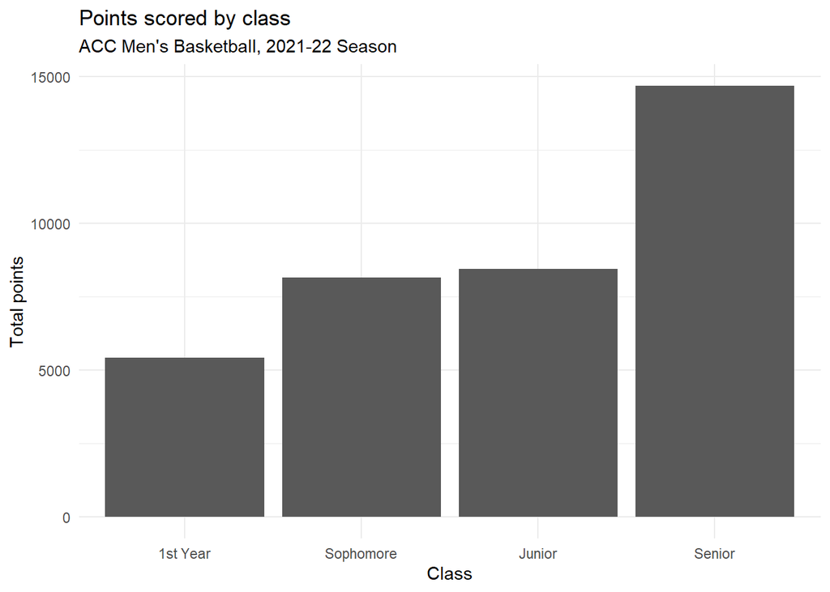

```r
ggplot(graph_data,
       aes(x = reorder(class, class_num),  # reorder by num version
           y = total_pts)) +
  geom_bar(stat = "identity") +
  theme_minimal() +
  labs(x = "Class",
       y = "Total points",
       title = "Points scored by class",
       subtitle = "ACC Men's Basketball, 2021-22 Season")
```

OK let’s take a step back. Not all uses of `mutate()` have to be as complicated as `case_when()`. Consider the following:

```r
pg_acc |>
  select(player, date, fga, fgm) |>
  head(10)
```

```
## ── Player Game Stats ─────────────────────────────────────────── toRvik 1.1.0 ──
```

```
## ℹ Data updated: 2022-09-12 16:58:37 EDT
```

```
## # A tibble: 10 × 4
##    player        date         fga   fgm
##    <chr>         <chr>      <dbl> <dbl>
##  1 Charlie Moore 2021-11-09    11     5
##  2 Charlie Moore 2021-11-13     8     1
##  3 Charlie Moore 2021-11-16    10     3
##  4 Charlie Moore 2021-11-21    10     6
##  5 Charlie Moore 2021-11-25     7     1
##  6 Charlie Moore 2021-11-26     9     6
##  7 Charlie Moore 2021-11-28    11     5
##  8 Charlie Moore 2021-12-01    10     5
##  9 Charlie Moore 2021-12-04     9     3
## 10 Charlie Moore 2021-12-08    12     4
```

This is the first 10 games the first player played in the ACC data. We see how many shots this player attempted and how many he made in each game. We could turn this into a percentage easily using `mutate()`.

```r
pg_acc |>
  select(player, date, fga, fgm) |>
  mutate(fg_pct = 100*(fgm/fga)) |>
  head(10)
```

```
## ── Player Game Stats ─────────────────────────────────────────── toRvik 1.1.0 ──
```

```
## ℹ Data updated: 2022-09-12 16:58:37 EDT
```

```
## # A tibble: 10 × 5
##    player        date         fga   fgm fg_pct
##    <chr>         <chr>      <dbl> <dbl>  <dbl>
##  1 Charlie Moore 2021-11-09    11     5   45.5
##  2 Charlie Moore 2021-11-13     8     1   12.5
##  3 Charlie Moore 2021-11-16    10     3   30
##  4 Charlie Moore 2021-11-21    10     6   60
##  5 Charlie Moore 2021-11-25     7     1   14.3
##  6 Charlie Moore 2021-11-26     9     6   66.7
##  7 Charlie Moore 2021-11-28    11     5   45.5
##  8 Charlie Moore 2021-12-01    10     5   50
##  9 Charlie Moore 2021-12-04     9     3   33.3
## 10 Charlie Moore 2021-12-08    12     4   33.3
```

Maybe this is too bouncy game by game. We could instead calculate the field goal percentage for each player’s season using `group_by()` and `summarize()`.

```r
pg_acc |>
  select(player, date, fga, fgm) |>
  group_by(player) |>
  summarize(tot_fga = sum(fga),
            tot_fgm = sum(fgm)) |>
  mutate(fg_pct = 100*(tot_fgm/tot_fga)) |>
  head(10)
```

```
## # A tibble: 10 × 4
##    player             tot_fga tot_fgm fg_pct
##    <chr>                <dbl>   <dbl>  <dbl>
##  1 Abe Atiyeh               0       0  NaN
##  2 Aidan Fisch              1       0    0
##  3 AJ Griffin             296     146   49.3
##  4 Al-Amir Dawes          294     119   40.5
##  5 Alex Hemenway          121      50   41.3
##  6 Alex Nunnally            0       0  NaN
##  7 Alondes Williams       477     242   50.7
##  8 Andrew Kenny             4       0    0
##  9 Anthony Harris          27      13   48.1
## 10 Anthony Mathis Jr.       2       0    0
```

We have two problems here. First, we have some players who didn’t attempt any shots so they get `NaN` for their shooting percentage. Second, we probably don’t want to see this in alphabetical order. So we can use `arrange(desc())` to sort it from highest to lowest.

```r
pg_acc |>
  select(player, date, fga, fgm) |>
  group_by(player) |>
  summarize(tot_fga = sum(fga),
            tot_fgm = sum(fgm)) |>
  mutate(fg_pct = 100*(tot_fgm/tot_fga)) |>
  arrange(desc(fg_pct)) |>
  head(10)
```

```
## # A tibble: 10 × 4
##    player         tot_fga tot_fgm fg_pct
##    <chr>            <dbl>   <dbl>  <dbl>
##  1 Chaz Owens           2       2  100
##  2 Duwe Farris          2       2  100
##  3 Elijah Taylor        3       3  100
##  4 Gabe Wiznitzer       1       1  100
##  5 Sam Bearden          1       1  100
##  6 Daniel Oladapo      25      20   80
##  7 J.R Konieczny        5       4   80
##  8 Mark Williams      266     191   71.8
##  9 Quincy Ballard      10       7   70
## 10 Jesse Edwards      165     114   69.1
```

But wait. Something still seems off here. Are these the best shooters from last season? Why not?

Maybe we should `filter()` the data so we only see the players who’ve taken at least 100 shots. What would that look like?

```r
pg_acc |>
  select(player, date, fga, fgm) |>
  group_by(player) |>
  summarize(tot_fga = sum(fga),
            tot_fgm = sum(fgm)) |>
  mutate(fg_pct = 100*(tot_fgm/tot_fga)) |>
  filter(tot_fga > 100) |>
  arrange(desc(fg_pct)) |>
  head(10)
```

```
## # A tibble: 10 × 4
##    player         tot_fga tot_fgm fg_pct
##    <chr>            <dbl>   <dbl>  <dbl>
##  1 Mark Williams      266     191   71.8
##  2 Jesse Edwards      165     114   69.1
##  3 Sydney Curry       131      88   67.2
##  4 Kadin Shedrick     142      91   64.1
##  5 Paul Atkinson      291     172   59.1
##  6 Armando Bacot      429     244   56.9
##  7 Rodney Howard      130      73   56.2
##  8 Jordan Miller      262     147   56.1
##  9 James Karnik       233     130   55.8
## 10 Jake LaRavia       298     166   55.7
```

I realize we’re mixing up 2-point and 3-point shooting here but you get the idea.